# Community structure and collapses in multichannel food webs: Role of consumer body sizes and mesohabitat productivities - Dijoux - - Ecology Letters - Wiley Online Library

[Ecology Letters](https://onlinelibrary.wiley.com/journal/14610248)

[Early View](https://onlinelibrary.wiley.com/toc/14610248/0/0)

Letter

Full Access

# Community structure and collapses in multichannel food webs: Role of consumer body sizes and mesohabitat productivities

[Samuel Dijoux](https://onlinelibrary.wiley.com/action/doSearch?ContribAuthorStored=Dijoux%2C+Samuel),

[David S. Boukal](https://onlinelibrary.wiley.com/action/doSearch?ContribAuthorStored=Boukal%2C+David+S),

First published: 25 May 2021

https://doi.org/10.1111/ele.13772

## Abstract

Multichannel food webs are shaped by the ability of apex predators to link asymmetric energy flows in mesohabitats differing in productivity and community traits. While body size is a fundamental trait underlying life histories and demography, its implications for structuring multichannel food webs are unexplored. To fill this gap, we develop a model that links population responses to predation, and resource availability to community-level patterns, using a tri-trophic food web model with two populations of intermediate consumers and a size-selective top predator. We show that asymmetries in mesohabitat productivities and consumer body sizes drive food web structure, merging previously separate theory on apparent competition and emergent Allee effects (i.e. abrupt population collapses) of top predators. Our results yield theoretical support for empirically observed stability of asymmetric multichannel food webs and discover three novel types of emergent Allee effects involving intermediate consumers, multiple populations or multiple alternative stable states.

## INTRODUCTION

Non-random distribution of trophic links underlies the persistence and stability of food webs (Otto et al., 2007; Rooney et al., 2006). Most food webs rely on the linkage of alternative asymmetric energy sources by predators at higher trophic levels (Barnes et al., 2018; McCann & Rooney, 2009; Rooney et al., 2008). Asymmetric energy flows strengthen the resilience of food webs (Rooney et al., 2006; Wolkovich et al., 2014), for example, by reducing population fluctuations and subsequent extinction cascades due to the paradox of enrichment (Dolson et al., 2009; Otto et al., 2007). Asymmetric energy flows often arise in freshwater ecosystems when mobile generalist predators link different mesohabitats, such as the littoral, pelagic and benthic habitats in lentic systems (Dolson et al., 2009; Marklund et al., 2018; Schindler & Scheuerell, 2002) or downstream and upstream areas in lotic systems (Lapointe et al., 2010; Rosenblatt & Heithaus, 2011). Energy in these mesohabitats often comes from different sources, and the flows differ in turnover and production rates (Rooney & McCann, 2012). In lentic systems, energy flow driven by photosynthesis in the more productive ‘green’ pelagic mesohabitat is usually faster than the flow driven by decomposers that depend on detritus and dissolved organic carbon in the ‘brown’ benthic mesohabitat (Zou et al., 2016).

Asymmetries in regulatory processes within multichannel food webs can influence the coexistence of competing species at intermediate trophic levels. Such asymmetries can arise in bottom-up regulatory processes from differences in basal productivity rate and prey biomass (Chesson & Kuang, 2008; DeCesare et al., 2010) or in top-down processes stemming from differences in the feeding behaviour of the top predator (Marklund et al., 2019; Post et al., 2000) and hence asymmetric predation pressure (Rooney et al., 2006; Wolkovich et al., 2014). In particular, linkage by top predators may influence communities in different mesohabitats in a way that either permits their coexistence or makes the least resilient community vulnerable to extinctions as suggested by earlier work on apparent competition in simple food web modules (Chase, 1999; Holt et al., 1994).

Asymmetric energy flows in multichannel food webs relate to the limiting similarity hypothesis (MacArthur & Levins, 1967), which posits that increasing niche overlap of co-occurring species diminishes their ability to coexist (Abrams & Rueffler, 2009; Meszéna et al., 2006). For example, species competing for a common resource and sharing the same predator can only coexist if they differ sufficiently in morphological or physiological traits, niche overlap and environmental requirements (Leibold, 1996, 1998). Other studies, however, highlighted possible coexistence of similar species due to asymmetric predation pressure (Holt et al., 1994) or due to varying fitness caused by variable phenotypes (Godoy et al., 2018; McPeek, 2019) or variable body sizes.

Food webs can also undergo abrupt ecological regime shifts when they exceed their ecological stability boundaries, leading to a switch between alternative stable states (May, 1977; Scheffer et al., 2001). These shifts occur in response to external perturbations such as eutrophication in freshwater (Folke et al., 2004; Scheffer & van Nes, 2007) and marine habitats (Möllmann & Diekmann, 2012; Muthukrishnan et al., 2016) or arise from positively reinforcing feedbacks to population dynamics such as Allee effects (Beisner et al., 2003; Oliver et al., 2015; de Roos & Persson, 2002). Various mechanisms can generate alternative stable states in food webs (reviewed in Schröder et al., 2005 and Gårdmark et al., 2015). For example, prey size refugia can lead to alternative stable states at intermediate nutrient levels in a food web consisting of two consumers sharing the same resource and predator (Chase, 1999, 2003). However, the propensity of multichannel food webs to ecological regime shifts has not yet been addressed.

Body size and resource productivity are ubiquitous drivers of community structure (Persson et al., 2014). Different community size spectra also characterize the fast- and slow-energy channels in aquatic food webs (Mehner et al., 2018): pelagic habitats are dominated by small-bodied phytoplankton and zooplankton, while benthic habitats host mainly larger-bodied macroinvertebrates (McCann & Rooney, 2009). The combined asymmetries in consumer body sizes and energy partition across mesohabitats may stabilize multichannel food webs (Rooney & McCann, 2012) or promote population collapses (de Roos & Persson, 2002) and alternative stable states (Chase, 2003), but we lack quantitative theory to resolve these interacting roles of consumer body size and resource productivity in the structuring of multichannel food webs.

To fill these gaps, we modelled the effect of varying body sizes and mesohabitat productivities on multichannel food webs. We focused on a case in which a top predator integrates two tri-trophic chains (as in Post et al., 2000) with size-structured populations of intermediate consumers that differ in body size using a modified tri-trophic chain model by de Roos and Persson (2002). This food chain model exhibits an emergent Allee effect due to predation-induced competitive release in the prey (Gårdmark et al., 2015) and the possibility of sudden predator collapse. Integrating two such food chains in different mesohabitats with a shared top predator opens the possibility for additional, qualitatively different community structures and steady-state transitions. We thus examined how differences in productivity and consumer body sizes affect consumer life histories, the structure of each food chain, apparent competition between the intermediate consumers and the persistence of the top predator. We were particularly interested in the combinations of consumer body sizes and habitat productivities that (1) enabled coexistence of the intermediate consumers when linked by the top predator and (2) lead to alternative stable states and possible collapses of top predator or intermediate consumer populations.

## METHODS

### Food web structure

Our minimal multichannel, tri-trophic food web includes seven possible communities differing in the presence of the intermediate consumers and the top predator (Communities 0–6 in Figure 1). For convenience, we refer to the mesohabitats as pelagic (*i* = 1) and benthic (*i* = 2), each with its own basal resource *R*<sub>i</sub> and intermediate consumer species *C<sub>i</sub>*, and apex predator *P* integrating both habitats. We begin by outlining expected transitions between these communities. Increasing productivity in each mesohabitat should lead to lengthening of the food chain and successful establishment of the consumer followed by the top predator (Fretwell, 1987; Oksanen et al., 1981) (community state transitions 0 → 1 → 4 and 0 → 3 → 6 in Figure 1). Benthic and pelagic consumers coexist in the absence of the top predator if each mesohabitat is sufficiently productive (Community 2). Successful invasion of the top predator in this community (transition 2 → 5) may subsequently affect consumer coexistence and lead to the exclusion of the less resilient consumer due to apparent competition (transition 5 → 4 or 5 → 6 in Figure 1). Possible alternative stable states involving two or more of these communities are described in Results.

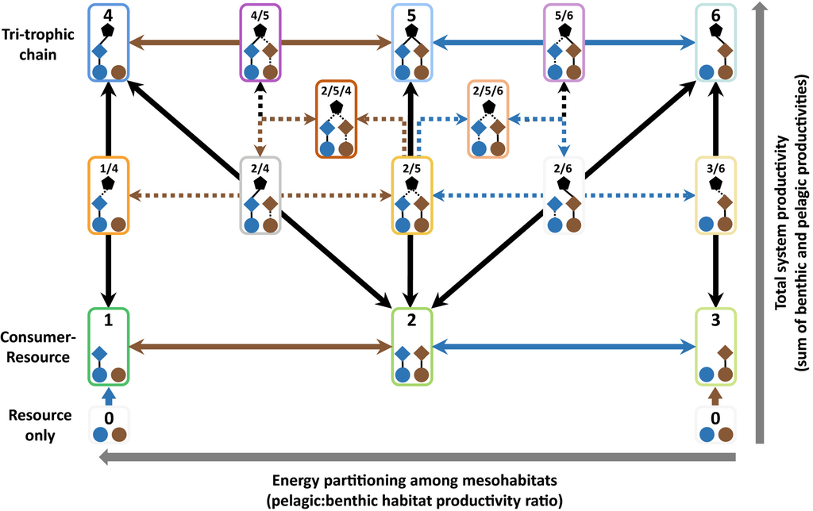

**FIGURE 1**

Classification of all possible scenarios of community assembly in the multichannel food web. Populations and trophic links: top predator (pentagons), consumers (diamonds) and resources (circles) linked by stable (solid lines) or bistable (dotted lines) trophic links; pelagic species in blue, benthic species in brown. Transitions between possible community states (numbered rectangles) correspond to the invasion/extinction threshold of one consumer (blue or brown arrows), or top predator (black arrows). Dotted arrows = transitions between communities with two to three alternative stable states (multiple numbers separated by slashes). Grey arrows illustrate gradients of energy partitioning among mesohabitats and total system productivity

### Population structure and dynamics

In our model, the top predator *P* with a fixed body size feeds indiscriminately on the size-structured populations of intermediate consumers *C*<sub>1</sub> and *C*<sub>2</sub>, while each consumer population feeds on its own basal resource that follows a semi-chemostat dynamics with carrying capacity *K<sub>i</sub>* and flow-through rate *ρ<sub>i</sub>* (*i* = 1, 2). We keep the same model structure and parameter values used in de Roos and Persson (2002) as a baseline scenario for the benthic food chain *R*<sub>2</sub>–*C*<sub>2</sub>–*P* and modify them for the pelagic food chain *R*<sub>1</sub>–*C*<sub>1</sub>–*P* (see Text S1 and Tables S1–S4 for details). We also assume that the pelagic resource *R*<sub>1</sub>has a faster turnover rate than the benthic resource *R*<sub>2</sub> (Fortier et al., 1994) and set *ρ*<sub>1</sub> = 2 *ρ*<sub>2</sub>.

The top predators feed indiscriminately on vulnerable individuals from both consumer populations when present, following a Holling Type II functional response. Predator biomass increases by converting ingested prey biomass and declines exponentially in the absence of consumers (see Text S1 and Tables S1–S4 for a full model description). In sum, both tri-trophic food chains in our model have identical properties except the mesohabitat productivity and the ratio of consumer body sizes, although the model could be easily modified to further explore the consequences of, for example, consumer-specific functional response parameters or different size scaling of the vital rates.

We focus on three key properties that can affect the community structure and transitions including the emergent Allee effects: consumer size ratio *β* and the productivity in each mesohabitat, which we attribute to the resource carrying capacities *K*<sub>1</sub> and *K*<sub>2</sub>. We first quantify the impact of consumer body size and habitat productivity on its ontogeny including predation risk, population growth rate and birth rate with and without predation. We then examine the effects of consumer body size and habitat productivity on the structure of each food chain and the whole food web to understand how asymmetries in consumer body size and mesohabitat productivity influence the apparent competition between intermediate consumers and the community structure (Figure 1). We solve Eqs. (S7)–(S11) numerically using the R package *PSPManalysis* version 3.1.2 (de Roos, 2021) to track the system equilibria and detect thresholds associated with successful establishment or collapse of intermediate consumers and the top predator.

## RESULTS

### Effects of body size, habitat productivity and predation on consumer life history

Body size has a strong effect on nearly all aspects of the intermediate consumer life history (Figure 2). Larger consumers take longer time to reach their asymptotic size but benefit from an earlier escape from predation, while very small consumers stay vulnerable to predation even as adults (Figure 2a). In the absence of predation, larger consumers have faster population-level growth rates (Figure 2b) but lower birth rates than smaller consumers (Figure 2c). As a result, the critical resource density required to sustain the consumer population in the absence of predation is almost independent of the consumer relative body size, although it is slightly higher in smaller consumers (black line in Figure 2d).

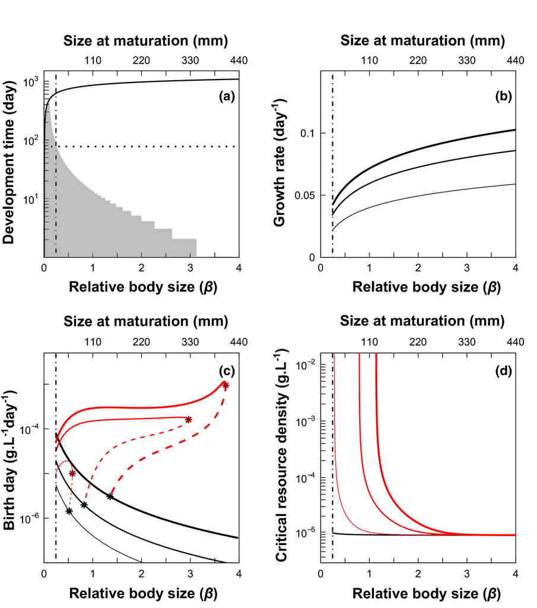

**FIGURE 2**

Influence of consumer relative body size *β* on key life history characteristics (a), population growth rate (b), birth rate (c) and critical resource density (d). (a) Grey area: consumers vulnerable to predation (daily resolution); black dotted line = maturation time; black solid line = time to reach maximum size, defined as age when individual growth rate declines below 0.01 mm day<sup>−1</sup>; resource level *R* fixed at ca. 3 × 10<sup>−4</sup>g L<sup>−1</sup>. (b and c) Population-level rates without predation (black lines) and with predation (red lines, c); resource carrying capacity fixed at *K* = 3 × 10<sup>−5</sup> (thin lines), 8 × 10<sup>−5</sup> (medium lines) and 3 × 10<sup>−4</sup>g L<sup>−1</sup> (thick lines). (d) Critical resource density without predation (black line) and under additional mortality of vulnerable juveniles (*µ*<sub>P</sub> = 0.1, 0.5 and 0.9; thin, medium and thick red lines). Other parameters as in Table S1. Community structure in panel C: solid lines = stable equilibria dashed lines = unstable equilibria of the tri-trophic chain; black points = predator invasion thresholds, red points = predator persistence thresholds; dash-dotted line = adult predation vulnerability threshold

Size-dependent predation releases the survivors from intraspecific competition and leads to higher birth rates relative to the non-predated population if some juvenile consumers are invulnerable to predation (*β* > 0.245, size at maturation *l<sub>j</sub>* >27 mm; red vs. black lines in Figure 2c). Increased mortality of the vulnerable juveniles also increases the critical resource density, especially for smaller consumers, and can drive small consumers extinct (red lines in Figure 2d) when the increased resource-dependent growth and birth rates (Figure 2b and c) cannot compensate for the increased mortality even at very high productivity levels. In what follows, we constrain our analyses to sufficiently large consumers with invulnerable adults (*l<sub>j</sub>* ≥ *l<sub>v</sub>* =27 mm, i.e. *β* ≥ 0.245).

### Tri-trophic chain: Role of intermediate consumer body size and mesohabitat productivity

For a wide range of consumer body sizes, the food chain lengthens as the habitat productivity increases and exhibits an emergent Allee effect in the top predator with two alternative stable states at intermediate habitat productivity levels (community state 1/4; Figure 3a). That is, a relatively high habitat productivity is required for the top predator population to establish, but established top predators can sustain lower habitat productivity as they modify the stage structure of the consumer population (de Roos & Persson, 2002; also Figure 4a for *β* = 1.2, i.e. *l<sub>j</sub>* =132 mm). The food chain collapses abruptly to a stable consumer–resource equilibrium when the habitat productivity decreases below the top predator persistence level (Figure 4a). The productivity threshold required for consumer establishment is essentially independent of consumer body size (compare Figure 2d), but those associated with top predator establishment and collapse are highly sensitive to consumer body size: top predators feeding on consumers characterised by larger body sizes require more resources to survive because the consumers are born larger and outgrow the predation size window earlier (Figure 3a, compare Figure 2a). The predator cannot survive when all consumers become invulnerable (*β* > ca. 3.8, *l<sub>b</sub>* >27 mm; Figure 3a).

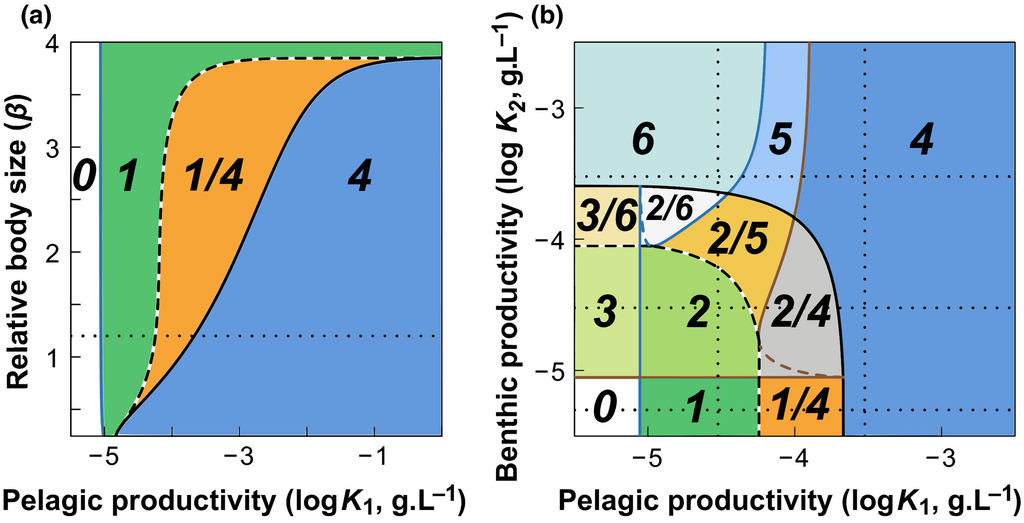

**FIGURE 3**

Changes in community structure of the tri-trophic food chain (a) and the multichannel food web (b) along gradients of mesohabitat productivity and consumer body size. Community structures, numbered as in Figure 1: resource-only equilibrium (0, white), consumer–resource equilibria (green, 1–3), four-species equilibria (blue, 4 and 6), and coexistence of all five species (blue, 5). Solid lines: invasion thresholds of pelagic (*C*<sub>1</sub>, blue) and benthic (*C*<sub>2</sub>, brown) consumers and the top predator (black). Dashed lines: invasion thresholds of pelagic (blue) and benthic (brown) consumers in an unstable equilibrium with top predator and extinction threshold of top predator with one or both consumers present (black). Parameters: (A) *K*<sub>2</sub> = 5 × 10<sup>−6</sup>g L<sup>−1</sup>, (b) *β* = 1.2, other values as in Table S1. Dotted lines: (a), *β* and *K*<sub>2</sub> values used in Figure 4; (b), *K*<sub>1</sub> and *K*<sub>2</sub> values used in Figure 5

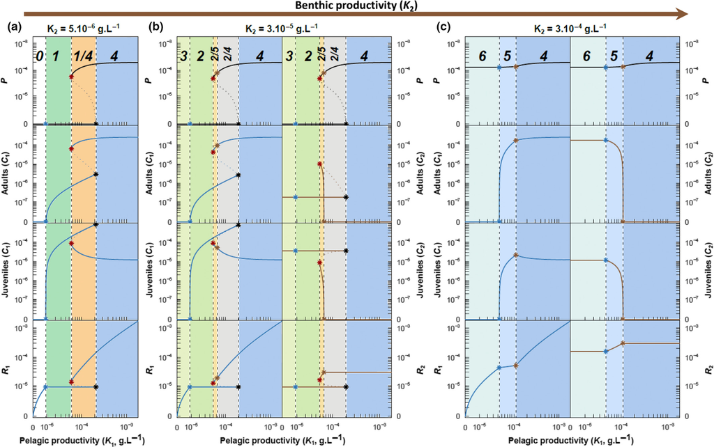

**FIGURE 4**

Emergent Allee effects in tri-trophic chain (a) and multichannel food web (b) and community transition between consumer coexistence and exclusion (c) along the pelagic productivity gradient. Parameter values: *β* = 1.2; *K*<sub>2</sub> = 5 × 10<sup>−6</sup> (a), 3 × 10<sup>−5</sup> (b) and 3 × 10<sup>−4</sup>g L<sup>−1</sup> (c), that is, benthic resource productivity increasing from (a) to (c). Other parameters as in Table S1. Solid lines: stable equilibria; dotted lines: unstable equilibria. Threshold productivity values marked by vertical dotted lines: invasions of pelagic (blue points) and benthic (brown points) consumer, top predator invasion (black points), top predator collapse (red points). Top predator panel duplicated in (b) and (c) to enable comparison within each mesohabitat. Community structures numbered as in Figure 1. Axes scaling: *x* axis transformed as log<sub>10</sub>(*x* + 10<sup>−5</sup>); *y* axis transformed as log<sub>10</sub>(*y* + 10<sup>−8</sup>) for juvenile and adult consumers and as log<sub>10</sub>(*y* + 10<sup>−6</sup>) for resources and top predator

### Multichannel food web: Role of asymmetries in intermediate consumer size and mesohabitat productivities

Coexistence and exclusion of apparent competitors are determined by their relative ability to sustain predation pressure, mediated by the mesohabitat-specific critical resource density (Figure 2d). Here, we analyse the effects of varying mesohabitat productivities and consumer body size on the structure of the multichannel food web, with emphasis on the coexistence of both intermediate consumers. We found surprisingly complex patterns of consumer body size ratios and habitat productivities required for their coexistence with the top predator. We first outline the range of habitat productivity levels that maintain both benthic and pelagic consumers of a given size ratio in the food web and subsequently provide more detailed results on body size differences that enable consumer coexistence and top predator persistence at given productivity levels in one of the mesohabitats (community state 5 and states 2/5, 4/5, 5/6, 2/4/5 and 2/5/6 that include state 5 as one of the alternatives; see Figure 1).

For a given consumer body size ratio *β*, the food web structure is driven by the pelagic–benthic habitat productivity ratio (expressed as the relative contribution of the pelagic habitat *K*<sub>1</sub>/(*K*<sub>2</sub> + *K*<sub>1</sub>); abbreviated as PB ratio) and the total amount of resources required to sustain the top predator population. This amount is determined by the sum of resource carrying capacities *K*<sub>1</sub> + *K*<sub>2</sub> (hereafter ‘total carrying capacity’, abbreviated as TCC), irrespective of the PB ratio when both consumers are of similar size as in Figure 3b, or depends on both the PB ratio and TCC when the pelagic and benthic consumers differ substantially in size (see below). Resource carrying capacity in the given habitat determines the invasion threshold of each intermediate consumer (Figures 2d and 5), while the total amount of resources required to sustain the top predator population determines its invasion and collapse thresholds (Figure S1). Competitive exclusion and coexistence of the two intermediate consumers when linked by the top predator are driven mainly by the PB ratio (Figure 3b and S3).

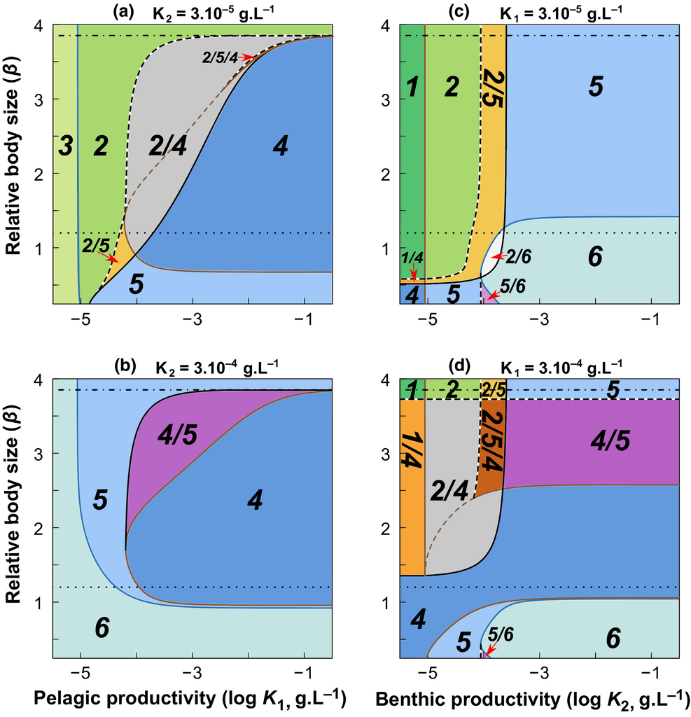

**FIGURE 5**

Dependence of community structure of the multichannel system on resource productivity and consumer relative body size *β*. Resource carrying capacity always fixed in one habitat: *K*<sub>2</sub> = 3 × 10<sup>−5</sup> (a) and 3 × 10<sup>−4</sup>g L<sup>−1</sup> (b); *K*<sub>1</sub> = 3 × 10<sup>−5</sup> (c) and 3 × 10<sup>−4</sup>g L<sup>−1</sup> (d). Other parameters as in Table S1. Community structures numbered as in Figure 1; coexistence of all five species denoted by ‘5’. Line type and colour as in Figure 3. Dotted lines (*β* = 1.2): results shown in Figure 3b. Dash-dotted lines (*β* = 3.8): predation vulnerability limit of the pelagic consumer

Consumer coexistence along the habitat productivity gradients is promoted by larger body size differences. That is, the coexistence of all five species is constrained to a narrow range of PB ratios and sufficiently high TCC values for same-sized intermediate consumers (*β* ≈ 1; community states 5 and 2/5 in Figure 5 and S3d). When one of the consumers is substantially larger (*β* << 1 or *β* >> 1) and hence competitively superior (see above), all five species can coexist only if its habitat is moderately productive. High productivity in that habitat leads to competitive exclusion of the smaller consumer because the top predator population supported by the larger consumer imposes additional mortality that cannot be mitigated by increased resource productivity (Figure 2d), while lower productivity cannot support the larger consumer. On the other hand, coexistence is almost independent of the productivity in the smaller consumer's habitat as long as it can support the top predator (ca. *K*<sub>1</sub> > 1.5 × 10<sup>−4</sup> to 4 × 10<sup>−4</sup>g L<sup>−1</sup> in Figure S3a–c and *K*<sub>2</sub> > 9 × 10<sup>−5</sup>g L<sup>−1</sup> in Figure S3e–i).

Unequal consumer body sizes also underpin asymmetric roles of habitat productivities in the fate of the top predator. TCC values required for top predator persistence are nearly independent of the PB ratio for most consumer body size ratios *β* and increase with PB only when the pelagic consumers are much larger (*β* = 3 in Figure S1a). TCC thresholds associated with predator invasion are more sensitive to *β* and PB ratios: they decline with the PB ratio when *β* ≤ 1 and increase otherwise (Figure S1b). This asymmetric role of the pelagic and benthic habitat productivities is caused by the habitat-specific consumer vulnerability to predation driven by the size differences, as both consumers are equivalent in terms of contribution to the critical prey biomass required by the top predator (Figure S2). That is, a more productive pelagic habitat is required to sustain the top predator as *β* increases and the pelagic prey becomes less vulnerable (Figure S1a).

At low benthic productivities *K*<sub>2</sub>, all five species therefore coexist if pelagic consumers are sufficiently small and pelagic productivity sufficiently high (community state 5; ca. *β* < 0.66, i.e. *l<sub>j</sub>* <73 mm for *K*<sub>1</sub> > 10<sup>−4</sup> g L<sup>−1</sup> in Figure 5a). Surprisingly, coexistence is also possible if the pelagic consumers are larger and pelagic productivity intermediate (community state 2/5; up to *β* = 1.5, i.e. *l<sub>j</sub>* =165 mm for *K*<sub>1</sub> between ca. 10<sup>−5</sup> and 10<sup>−4</sup>g L<sup>−1</sup> in Figures 3b and 5a; see also Figure 4b and S4a–d). Coexistence at high benthic productivity *K*<sub>2</sub> requires sufficiently large pelagic consumers (ca. *β* > 0.9, i.e. *l<sub>j</sub>* >100 mm in Figure 5b) in a moderately productive pelagic mesohabitat; the range of pelagic productivity leading to possible coexistence increases with *β* (community states 5, 4/5 and 2/4/5; Figure 5b and S4G-I; see also Figure 4c). Intermediate benthic productivities *K*<sub>2</sub> combine the outcomes for low and high *K*<sub>2</sub>, that is, all five species can coexist when sufficiently high pelagic productivity supports small pelagic consumers or when large pelagic consumers are constrained by intermediate pelagic productivity (community states 5, 2/5, 4/5 and 2/4/5; Figure S4e and f).

We observe similar patterns for fixed pelagic productivities *K*<sub>1</sub>: coexistence is possible if benthic consumers are substantially larger and occupy a less productive habitat or if they are substantially smaller and live in a more productive habitat than the benthic consumers (community states 5, 2/5, 4/5, 5/6, 2/4/5 and 2/5/6; Figure 5c and d and S5). Coexistence is less likely, that is, occurs for a smaller range of *β* and *K*<sub>2</sub>, as the pelagic productivity becomes very low (Figure S5a) or very high (Figure 5d and S5g–i). At intermediate values of pelagic productivity, even similarly sized benthic and pelagic consumers may however coexist within a range of intermediate benthic productivity (community state 2/5 in Figure 5c and states 5 and 2/5 in Figure S5b–f).

### Emergent Allee effects and alternative stable states in the multichannel food web

We identified nine possible alternative stable state configurations in the food web and classify them into four groups. First, they include the ‘classical’ *emergent Allee effect in the top predator* associated with its sudden collapse (de Roos & Persson, 2002; Figure 6a) when one or both consumer populations are present (community states 1/4, 3/6 and 2/5 in Figures 1 and 5). Second, an *emergent Allee effect in an intermediate consumer* represents the collapse of a competitively inferior consumer population due to apparent competition when all other species are present (community states 4/5 and 5/6 in Figure 1). Third, an *emergent two*-*species Allee effect* is associated with the invasion of the competitively inferior consumer species upon the sudden collapse of the top predator or its disappearance after the top predator establishes in the trophic food chain (community states 2/4 and 2/6 in Figure 1). Finally, the community can have *three* alternative stable states: presence of the top predator with one or both consumer populations or both consumer populations without the top predator (community states 2/5/4 and 2/5/6 in Figure 1). This outcome combines the emergent Allee effects in the top predator and in an intermediate consumer; we call it a *cascading emergent Allee effect* characterised by consecutive (Figure 6b) or nested (Figure 6c) population collapses of the top predator and one or both consumers. While the consecutive collapses enable the food web structure pass through all three alternative stable states through gradual change of the environmental conditions alone, the nested collapses make one of the stable states unreachable by gradual change.

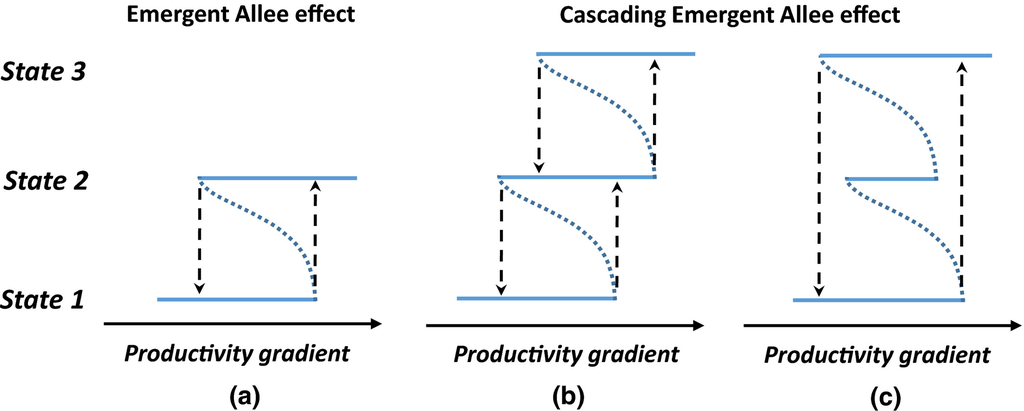

**FIGURE 6**

Diagram of (a) emergent Allee effect and (b and c) cascading emergent Allee effects along a productivity gradient. Dashed arrows = sudden community transitions between alternative system states; stable states (solid blue lines) separated by unstable equilibria (dotted lines). In cascading emergent Allee effect, sudden community transitions follow in succession (b; e.g. community state 2/5/6 in Figures S3b and S5b) or in a single event (c; community state 2/5/4 in Figure S4c and d). Note that stable state 2 cannot be reached by gradual changes in (c)

We observed emergent Allee effects across a wide range of habitat productivities (Figure 3 and S3) and consumer size ratios (Figure 5 and S4–S5). Emergent Allee effects in the top predator and the two-species Allee effects (community states 1/4, 2/4, 2/5, 2/6 and 3/6) occurred at all consumer size ratios *β* but were restricted to intermediate TCC levels; the exact TCC range varied with the PB ratio when *β* deviated strongly from unity (Figure 5 and S3). Emergent Allee effects in intermediate consumers (community states 4/5 and 5/6) occurred only when *β* deviated strongly from unity and TCC levels were high enough for the top predator to persist (Figure 5b and S3–S5). Cascading emergent Allee effects (community states 2/5/4 and 2/5/6) appeared mainly for sufficiently dissimilar consumer body size ratios and intermediate TCC levels (Figure 5a and d, S3b, S3E–I, S4e–g and S5b and S5e–i). They almost always included consecutive population collapses (Figures S6b and S7a and c) and very rarely the nested collapse (community states 2/4 and 2/5/4 in Figure S4c and d). Finally, emergent Allee effects in our simulations predominately affected communities in which the top predator gained a feeding link to the pelagic or both consumers (community states 1/4, 2/4, 2/5 and 2/4/5) or in which apparent competition drove benthic consumers extinct (4/5; Figure 5b and d). This was likely caused by the constant size of benthic consumers in our analyses (see Text S2 for details).

## DISCUSSION

Variation in predator–prey body size ratios underpins the structure and stability of food webs (Brose et al., 2006; Petchey et al., 2008). Furthermore, individual growth in size plays an important role in predator–prey interactions as large prey often become invulnerable to predation (Andersen & Beyer, 2006; de Roos & Persson, 2002). However, the importance of varying body sizes in multichannel food webs that arise in many aquatic and terrestrial ecosystems has not been explored. Here, we provided theoretical support for the key role of asymmetric body sizes and resource productivities in the empirically observed stability of multichannel food webs (Rooney et al., 2006). We also showed that alternative stable states in these food webs can go beyond the emergent Allee effect in the top predator (de Roos & Persson, 2002) and mutual exclusion via apparent competition (Chase, 1999; Holt et al., 1994) as we discovered three new types of emergent Allee effects affecting intermediate consumers or multiple populations or involving multiple alternative stable states. Our results emphasise the need to jointly consider the strength of bottom-up regulatory processes, individual ontogeny and size-dependent interactions to improve our understanding of the responses of multichannel food webs to environmental change.

### Multichannel food webs and apparent competition

We showed that body sizes of the intermediate consumers and energy partition between mesohabitats jointly determine the limits of species coexistence in multichannel food webs. Classic theory of apparent competition predicts that the prey resilient to the highest predation pressure prevails (Holt et al., 1994). Further extensions examining the combined roles of apparent and exploitative competition found that consumer coexistence requires a trade-off in the ability to dominate in each type of competition (Holt et al., 1994) and that habitat productivity drives the outcome (Chase, 1999; Leibold, 1996). That is, species dominating in exploitative competition should be gradually replaced by species resistant to predation as productivity increases, with coexistence possible at intermediate productivity levels (Leibold, 1996). This will often mean that small and large species will respectively dominate at low and high habitat productivity if predators cannot feed on large prey (Chase, 1999, 2003).

As a consequence, consumer coexistence in our model was primarily driven by the ratio of productivity in both linked mesohabitats when the two consumers were similarly sized and by productivity in the larger consumer's mesohabitat (i.e. similar to the findings by Chase (1999) and Leibold (1996)) when their sizes differed substantially. These conditions ensured sufficient productivity in each mesohabitat to meet the increased critical resource density requirements due to the predation pressure on vulnerable juveniles. We conclude that a ‘symmetry in asymmetries’ is required for consumer coexistence in multichannel food webs: asymmetry in body size, leading to different critical resource density at a given level of predation risk, must compensate for a mirror asymmetry in energy partitioning such as smaller consumers living in a more productive mesohabitat.

### Emergent Allee effects, alternative stable states and catastrophic collapses

Increasing anthropogenic pressure on fish stocks through eutrophication and harvesting (Möllmann & Diekmann, 2012) has led to catastrophic declines of two thirds of freshwater and marine predatory fish, with an acceleration of 54% over the past 40 years (Christensen et al., 2014; Otto, 2018). While these declines can be reversible (Hutchings, 2000; Persson et al., 2007), they require disproportionately large efforts if the collapses associate with Allee effects that affect population resilience and recovery, promote alternative stable states in the system (van Kooten et al., 2005; Scheffer et al., 2001) and make the food webs vulnerable to sudden collapse (Gårdmark et al., 2015; Möllmann & Diekmann, 2012).

Here, we demonstrated that multichannel food webs can become disconnected not only by the loss of top predator but also by the loss of populations at intermediate trophic levels in response to increased productivity in the other mesohabitat, for example, due to eutrophication. Our results imply that multichannel food webs show the highest propensity for alternative stable states at highly unequal consumer body sizes and intermediate habitat productivity levels, which may guide future empirical studies on alternative stable states in such food webs. Intermediate levels of habitat productivity are also required for alternative stable states in the diamond and intraguild predation food web modules (Chase, 1999, 2003; Diehl & Feißel, 2000), suggesting that this pattern is independent of food web topology.

We did not observe alternative stable states affecting consumers via priority effects (Chase, 1999, 2003) as our model excludes exploitative competition. However, we identified other novel types of community transitions leading to the loss of the inferior consumer through an emergent Allee effect when (1) the top predator invades the system and the system shifts from separate consumer–resource pairs to a trophic chain, (2) increased or decreased productivity in one mesohabitat disrupts the energy balance and the system changes from a multichannel food web to a trophic chain and (3) cascading emergent Allee effects arise. In the latter case, we predict that the system can alternate between multiple stable states involving separate consumer–resource pairs, a trophic chain and the complete multichannel food web. This additional complexity may contribute to the limited evidence of alternative stable states on whole-ecosystem level (Schröder et al., 2005; but see Möllmann & Diekmann, 2012).

The emergent Allee effect in the top predator requires food- and size-dependent growth and size-dependent mortality of the consumers, but similar results can be obtained for size-structured predator population and predation risk given by the predator–prey body size ratio as long as the predation mortality induces competitive release in the prey (de Roos & Persson, 2002). The same mechanisms underpin the emergent Allee effects involving collapses of intermediate consumer populations, because they are caused by abrupt shifts in the critical resource density mediated by changes in predation mortality of vulnerable juveniles (Figure 2d). Although we have not run extensive simulations, we thus believe that our results do not critically depend on the stepwise predation mortality used for simplicity in (de Roos & Persson, 2002) and our model.

### Conclusions and future directions

Our model showed that asymmetries in consumer body sizes and mesohabitat productivities can explain empirical data on multichannel food webs (McCann & Rooney, 2009; Rooney et al., 2006). We conclude that further studies exploring the links between the size scaling of individual vital rates and the dependence of critical resource density on consumer body size and predation pressure can provide mechanistic insights in the structure and functioning of multichannel food webs, including their propensity to sudden collapses due to emergent Allee effects. In particular, different size scaling of energy intake and expenditure can shift the competitive dominance towards adults or juveniles and lead to adult- or juvenile-driven consumer–resource cycles (Huss et al., 2013) rather than an equilibrium (as in our model), with all but unknown consequences for the structure and dynamics of multichannel food webs (but see Post et al., 2000). Detailed understanding of the role of individual and species traits such as body size in multichannel food webs could also help identify communities and species vulnerable to regime shifts (Gårdmark et al., 2015) and suggest possible restoration approaches.

## DATA STATEMENT

No new data were used.

## ACKNOWLEDGEMENTS

We thank Andrea Landeira-Dabarca and two anonymous reviewers for detailed comments that helped us improve the manuscript. This research was supported by the Grant Agency of the Czech Republic, project nr. 14-29857S.

## AUTHORSHIP

DSB and SD designed the study. SD performed all numerical analyses with additional input from DSB. Both authors discussed the results and made suggestions for their presentation. SD wrote the first draft of the manuscript and DSB revised it.

Online Version of Record before inclusion in an issue

### Details

© 2021 John Wiley & Sons Ltd.

### Research funding

- Grantová Agentura České Republiky. Grant Number: project nr. 14-29857S

### Keywords

- [alternative stable states](https://onlinelibrary.wiley.com/action/doSearch?field1=Keyword&text1=alternative%20stable%20states)
- [Apparent competition](https://onlinelibrary.wiley.com/action/doSearch?field1=Keyword&text1=Apparent%20competition)
- [emergent Allee effects](https://onlinelibrary.wiley.com/action/doSearch?field1=Keyword&text1=emergent%20Allee%20effects)
- [limiting similarity](https://onlinelibrary.wiley.com/action/doSearch?field1=Keyword&text1=limiting%20similarity)
- [size-dependent predation](https://onlinelibrary.wiley.com/action/doSearch?field1=Keyword&text1=size%E2%80%90dependent%20predation)

### Publication History

- Version of Record online: 25 May 2021
- Manuscript accepted: 12 April 2021
- Manuscript revised: 19 January 2021
- Manuscript received: 03 December 2020